# PART II: ANALYSIS OF PROSPER LOAN DATA FROM 2005 TO 2014

# BY: DAVID UGOCHUKWU ASOGWA

## Investigation Overview

This data set is a loan data records from prosper Loan in the United States, it contains 113,937 loans with 81 variables on each loan, including loan amount, interest rate, current loan status, borrower income, and many others. The report in this part would be structured to provide summary of simple univariate relationships to multivariate relationships, this research provides answers to various questions like whether the monthly loan payment has a correlation or any relationship between loan original,amount, what is the spread of lterm of loan in loan status, identifying the frequency of the categorical variables; Term of loan, borrower's employment status, year of loan, and loan status, are there differences between loans depending on how the loan term large the original loan amount was. Key insights would be generated from this to be able to make a presentation with it. In spite of the fact that the dataframe has 81 features, this study is only interested in few of the features, and after the cleaning process, only the useful columns for the purpose of this study was saved and used for analysis.

# Distribution of Loan Amount

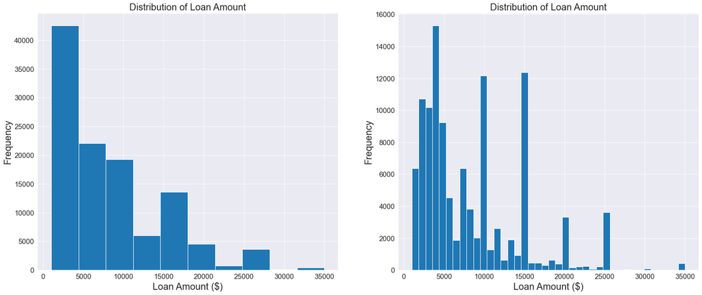

# Next up, monthly_payment of borrowers

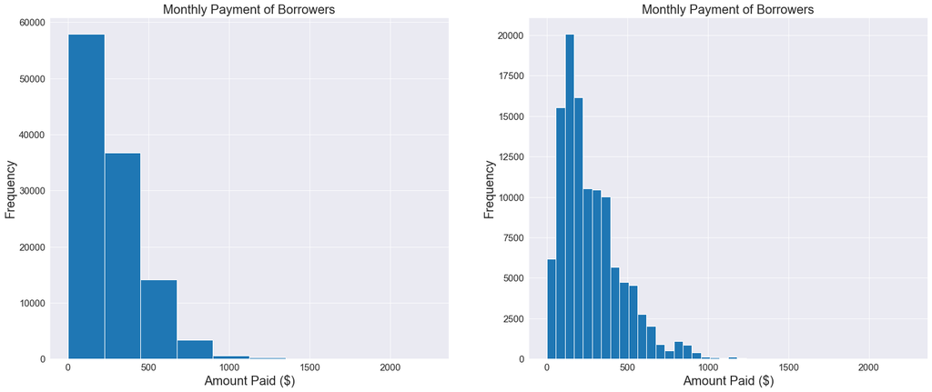

# The loan term appears to be an interesting feature

The loan term shows that majority of the loans taken are medium term loans with 77.14% of the loans, followed by the long and short term loans withh 21.43% and 1.43% of the total loans respectively.

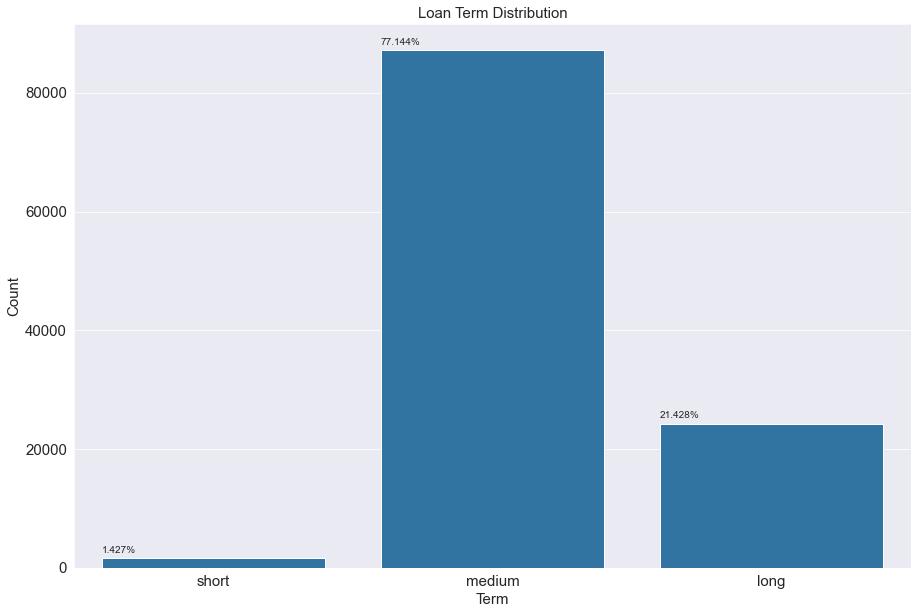

# Let's see what happens in the status column

This data explicitly shows that majority of the loans (49.29%) are still open while 33.66% are completed, which is actually a good thing. Only a few of the loans gave defaulted as seen in the past due bars. A small amount of loan have been cancelled within the period amounting to 0.004% and 0.18% of the loans are already making their final payment.

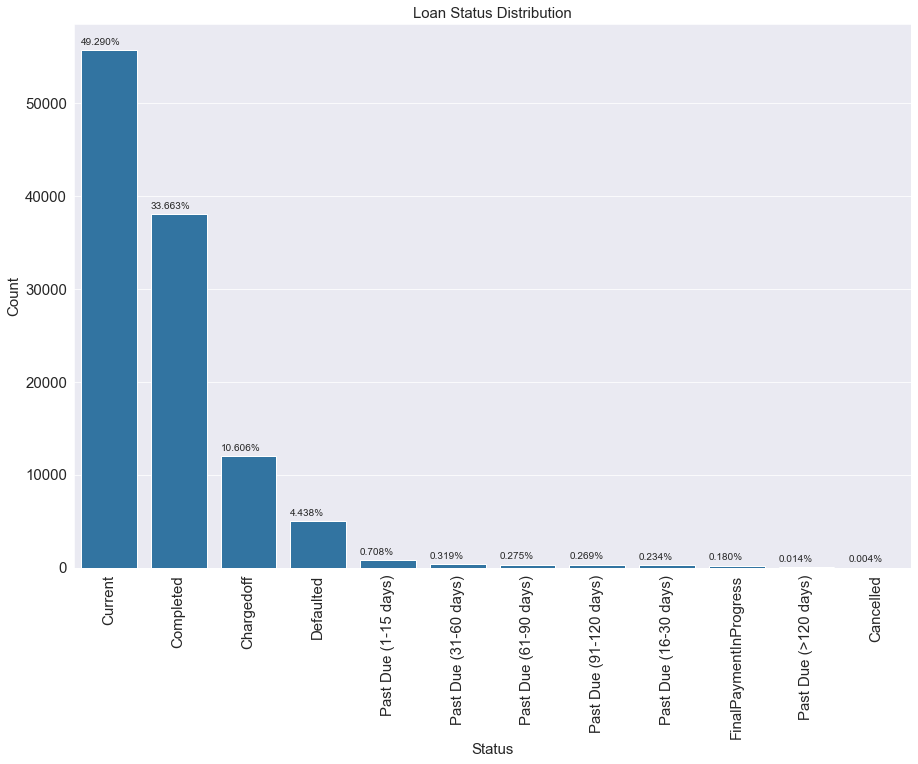